# CFRM 502, Winter 2020

# Instructor: Bahman Angoshtari

# Lecture 11

**Chapter 13:** long-memory time series model (fractional ARIMA), regression with time series errors (ARMAX)

**Chapter 14:** volatility, ARCH models

```r
# Setting parameters of the Jupyter notebook
sc = .75
options(repr.plot.width=16*sc,
        repr.plot.height=7*sc,
        repr.plot.pointsize = 13, # Text height in pt
        repr.plot.bg        = 'white',
        repr.plot.antialias = 'gray',
        #nice medium-res DPI
        repr.plot.res       = 300,
        #jpeg quality bumped from default
        repr.plot.quality   = 90,
        #vector font family
        repr.plot.family    = 'serif')
# Vector font family. 'sans', 'serif', 'mono' or a specific one
```

$\newcommand\Fc{\mathscr{F}}$ $\newcommand{\eps}{\varepsilon}$ $\newcommand{\Var}{\operatorname{Var}}$ $\newcommand\Cov{\operatorname{Cov}}$ $\newcommand\Corr{\operatorname{Corr}}$ $\newcommand{\sig}{\sigma}$ $\newcommand\Sig{\Sigma}$ $\newcommand{\al}{\alpha}$ $\newcommand{\gam}{\gamma}$ $\newcommand\Gam{\Gamma}$ $\newcommand\lam{\lambda}$ $\newcommand{\Del}{\Delta}$ $\newcommand\tht{\theta}$ $\newcommand{\Tht}{\Theta}$ $\newcommand\ph{\varphi}$ $\newcommand\om{\omega}$ $\newcommand\Om{\Omega}$ $\newcommand\rb{\bar{r}}$ $\newcommand{\Xb}{\bar{X}}$ $\newcommand{\Yb}{\bar{Y}}$ $\newcommand\Eb{\mathbb{E}}$ $\newcommand\Pb{\mathbb{P}}$ $\newcommand\Qb{\mathbb{Q}}$ $\newcommand\Rb{\mathbb{R}}$ $\newcommand\Zb{\mathbb{Z}}$ $\newcommand\Nb{\mathbb{N}}$ $\newcommand\Av{\textbf{A}}$ $\newcommand\Ev{\textbf{E}}$ $\newcommand\Dv{\textbf{D}}$ $\newcommand\Fv{\textbf{F}}$ $\newcommand\Gv{\textbf{G}}$ $\newcommand\Hv{\textbf{H}}$ $\newcommand\Kv{\textbf{K}}$ $\newcommand\Iv{\textbf{I}}$ $\newcommand\Pv{\textbf{P}}$ $\newcommand\Ov{\textbf{O}}$ $\newcommand\Sv{\textbf{S}}$ $\newcommand\Xv{\textbf{X}}$ $\newcommand\Yv{\textbf{Y}}$ $\newcommand\Zv{\textbf{Z}}$ $\newcommand\av{\mathbf{a}}$ $\newcommand\xv{\mathbf{x}}$ $\newcommand\yv{\mathbf{y}}$ $\newcommand\zv{\mathbf{z}}$ $\newcommand\Cv{\mathbf{C}}$ $\newcommand\mv{\mathbf{m}}$ $\newcommand\nv{\mathbf{n}}$ $\newcommand\pv{\mathbf{p}}$ $\newcommand\sv{\mathbf{s}}$ $\newcommand\wv{\mathbf{w}}$ $\newcommand\Wv{\textbf{W}}$ $\newcommand\alv{{\boldsymbol\al}}$ $\newcommand\betav{{\boldsymbol\beta}}$ $\newcommand\etav{{\boldsymbol\eta}}$ $\newcommand\epsv{{\boldsymbol\varepsilon}}$ $\newcommand\delv{{\boldsymbol\delta}}$ $\newcommand\Lamv{{\boldsymbol\Lambda}}$ $\newcommand\lamv{{\boldsymbol\lambda}}$ $\newcommand\muv{{\boldsymbol\mu}}$ $\newcommand\piv{{\boldsymbol\pi}}$ $\newcommand\Piv{{\boldsymbol\Pi}}$ $\newcommand\Gamv{{\boldsymbol\Gam}}$ $\newcommand\Phiv{{\boldsymbol\Phi}}$ $\newcommand\Sigv{{\boldsymbol\Sig}}$ $\newcommand\ah{\widehat{a}}$ $\newcommand\Pbh{\widehat{\Pb}}$ $\newcommand\phh{\widehat{\varphi}}$ $\newcommand\thth{\widehat{\theta}}$ $\newcommand\Ebh{\widehat{\Eb}}$ $\newcommand\Qh{\widehat{Q}}$ $\newcommand\Ih{\widehat{I}}$ $\newcommand\pih{\widehat{\pi}}$ $\newcommand\Pih{\widehat{\Pi}}$ $\newcommand\rh{\widehat{r}}$ $\newcommand\Sigvh{\widehat{\Sigv}}$ $\newcommand\Wh{\widehat{W}}$ $\newcommand\Fh{\widehat{F}}$ $\newcommand\Yh{\widehat{Y}}$ $\newcommand\Zh{\widehat{Z}}$ $\newcommand\Yvh{\widehat{\Yv}}$ $\newcommand\Ah{\widehat{\Ac}}$ $\newcommand\uh{\widehat{u}}$ $\newcommand\vh{\widehat{v}}$ $\newcommand\fh{\widehat{f}}$ $\newcommand\hh{\widehat{h}}$ $\newcommand\Bh{\widehat{B}}$ $\newcommand\Ovh{\widehat{\Ov}}$ $\newcommand\Xvh{\widehat{\Xv}}$ $\newcommand\rhoh{\widehat{\rho}}$ $\newcommand\nuh{\widehat{\nu}}$ $\newcommand\varphih{\widehat{\varphi}}$ $\newcommand\alh{\widehat{\al}}$ $\newcommand\thetah{\widehat{\theta}}$ $\newcommand\betah{\widehat{\beta}}$ $\newcommand\betavh{\widehat{\boldsymbol\beta}}$ $\newcommand\kaph{\widehat{\kappa}}$ $\newcommand\sigh{\widehat{\sigma}}$ $\newcommand\epsh{\widehat{\eps}}$ $\newcommand\epsvh{\widehat{\epsv}}$ $\newcommand\epst{\widetilde{\eps}}$ $\newcommand\muh{\widehat{\mu}}$ $\newcommand\dd{\mathrm{d}}$ $\newcommand\ee{\mathrm{e}}$

# 0. Overview of the lecture

- In this lecture, we start with an extension of ARIMA models for time series that have **long-memory**.
- These are processes whose autocorrelation decays slower than that of a regular ARIMA model, meaning that they retain a *"memory"* of their long past.
- We then consider **regression models** in which **errors are ARMA** process. These models bring together regression and time-series modeling.
- So far, we have focused on the conditional mean of a time series. In our third topic of today's lecture, we start the topic of volatility modeling by discussing ARCH processes.

## 1. Long-memory processes and fractional differencing

- Stationary ARMA(p,q) processes have the property that their ACF **decays exponentially to zero** as lag increases
- For unit-root non-stationary ARIMA(p,d,q) processes, it can be shown that the **sample** ACF converges to 1 as lag goes to infinity
- There are times series whose sample ACF falls into neither categories. Specifically, their sample ACF converges to zero but at a slower polynomial rate than those of stationary ARMA. Such processes are called **"long-memory"** time series

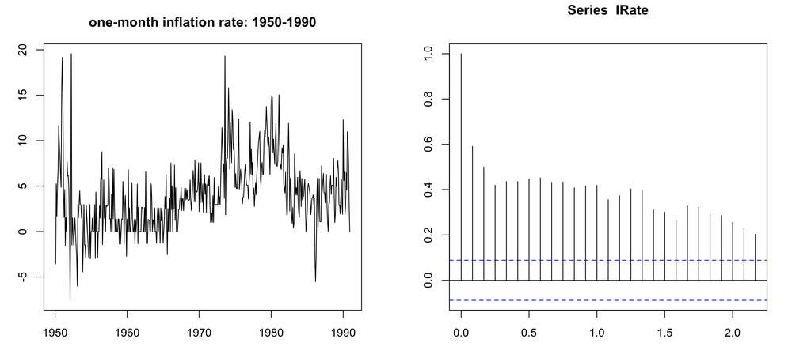

```r
par(mfrow=c(1,2));par(mar=c(3,3,3,3))
data(Mishkin, package = "Ecdat")
IRate = as.ts(Mishkin[,1], start=1950, frequency=12)
ts.plot(IRate, main="one-month inflation rate: 1950-1990")
acf(IRate)
```

- A known and well studied class of long-memory process are those created by **"fractional differencing,"** which we define next
- Recall again the lag operator $B r_t = r_{t-1}$.
- The regular differencing is $\Del r_t = $ $r_t - r_{t-1} = $ $r_t - B r_t =$ $ (1-B) r_t$
- So, we have $\Del =$ $ (1-B)$
- The 2-nd order differencing is

\begin{align*} \Del^2 r_t &= \Del(\Del r_t) = \Del( r_t - r_{t-1})\\\\ &= r_t - r_{t-1} - (r_{t-1}-r_{t-2})\\\\ &= r_t - 2 r_{t-1} + r_{t-2}\\\\ &= r_t - 2 B r_t + B^2 r_t =(1-2 B + B^2) r_t = (1-B)^2 r_t \end{align*}

- So, we may write $\Del^2 = (1-B)^2$
- Similar argument (using induction) shows that the $d$-th difference is given by

\begin{align*} \Del^d = (1-B)^d = \sum_{k=0}^d {d\choose k} (-B)^k \end{align*}

- Fractional difference is the extension of this formula to the case where $d$ is not an integer (that is, it is a fraction)
- Recall the Taylor expansion of the function $f(x)=(1-x)^d$ for $d>-1$

\begin{align*} (1-x)^d = \sum_{k=0}^\infty \frac{d(d-1)\dots(d-k+1)}{k!} (-x)^k \end{align*}

- Let us define, for a non-integer constant $d>-1$, and any integer $k\ge0$

\begin{align*} {d\choose k} := \frac{d(d-1)\dots(d-k+1)}{k!} \end{align*}

- Motivated by the Taylor expansion above, we define the fractional difference of any time series $\{r_t\}_{t=-\infty}^\infty$ to be

\begin{align*} \Del^d r_t = (1-B)^d r_t := \left(\sum_{k=0}^\infty {d\choose k}(-B)^k\right) r_t = \sum_{k=0}^\infty {d\choose k}(-1)^k r_{t-k} \end{align*}

- For finite times series $\{r_0,\ldots,r_T\}$, we define

\begin{align*} \Del^d r_t := \left(\sum_{k=0}^t {d\choose k}(-B)^k\right) r_t = \sum_{k=0}^t {d\choose k}(-1)^k r_{t-k};\qquad\qquad t\in\{0,\dots,T\}. \end{align*}

- Recall that for the inflation rate series, the unit-root tests where inconclusive

```r
library(tseries)
adf.test(IRate)
pp.test(IRate)
kpss.test(IRate)
```

```
	Augmented Dickey-Fuller Test

data:  IRate
Dickey-Fuller = -3.8651, Lag order = 7, p-value = 0.01576
alternative hypothesis: stationary
```

```
	Phillips-Perron Unit Root Test

data:  IRate
Dickey-Fuller Z(alpha) = -248.75, Truncation lag parameter = 5, p-value
= 0.01
alternative hypothesis: stationary
```

```
	KPSS Test for Level Stationarity

data:  IRate
KPSS Level = 2.51, Truncation lag parameter = 5, p-value = 0.01
```

- Maybe the difference order is something between 0 and 1?
- Let us calculate the fractional difference of `IRate` with $d=0.4$. This can be achieved with function `diffseries()` in `fracdiff` package.

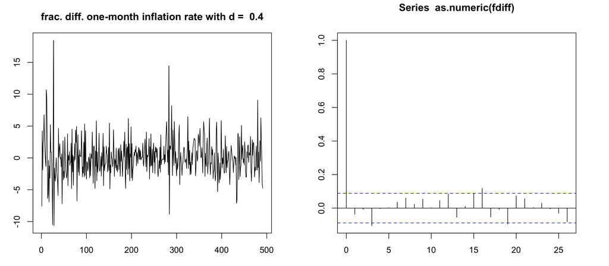

```r
library(fracdiff)
d=0.4
fdiff = diffseries(IRate,d)
par(mfrow=c(1,2));par(mar=c(3,3,3,3))
ts.plot(fdiff, main=paste("frac. diff. one-month inflation rate with d = ", d))
acf(as.numeric(fdiff))
```

- $\Del^{0.4}$`IRate` seems to be a weak WN!

## 1.1. Fractional ARIMA models

- The process $\{r_t\}$ is a **"Fractional ARIMA(p,d,q)"** process (also known as **"ARFIMA(p,d,q)"** model) if $\{\Del^d r_t\}$ is an ARMA(p,q) process.
- Note that in this definition, $d$ is any number (possibly non-integer) such that $d>-1$.
- A FARIMA(p,d,q) process is **stationary** if $\displaystyle -\frac{1}{2}< d < \frac{1}{2}$
- A FARIMA(p,d,q) process is stationary and has **long-memory** (that is, its ACF decays to zero with polynomial rate) if $\displaystyle 0<d<\frac{1}{2}$
- With this two results, we can decide about other values of $d$.
- For example, if $\{r_t\}$ is a FARIMA(p,1.3,q) process, then it is non-stationary.
- Its first difference $\{\Del r_t\}$ however is a ARFIMA$(p,0.3,q)$ process, which is a stationary long-memory process.
- Similarly, an ARFIMA(p,0.7,q) process is non-stationary, but, its first difference is an ARFIMA(p,-.3,q) process which is stationary but not long-memory.
- An ARFIMA(p,1.5,q) process $\{r_t\}$ is non-stationary and cannot be made stationary by taking regular difference. It may however become stationary by taking fractional differencing if the ARMA(p,q) process $\{\Del^{1.5} r_t\}$ does not have unit root.
- Let us illustrate fit a FARIMA model to the inflation rate series.
- First, we find the order of differencing. This can be done by the `fracdiff()` function of the `fracdiff` package

```r
fracdiff(IRate,nar=0,nma=0)
```

```
Call:
  fracdiff(x = IRate, nar = 0, nma = 0)

Coefficients:
        d
0.3775005
sigma[eps] = 2.931331
a list with components:
 [1] "log.likelihood"  "n"               "msg"             "d"
 [5] "ar"              "ma"              "covariance.dpq"  "fnormMin"
 [9] "sigma"           "stderror.dpq"    "correlation.dpq" "h"
[13] "d.tol"           "M"               "hessian.dpq"     "length.w"
[17] "residuals"       "fitted"          "call"
```

- The estimated fractional difference is $0.3775$
- Next, we fit an ARMA(p,q) model to $\Del^{0.3775}$`IRate` using `auto.arima()`

```r
library("forecast")
d=0.3775
fdiff = diffseries(IRate,d)
farima = auto.arima(as.numeric(fdiff), max.p=20, max.q = 20, max.d=0, ic="bic")
farima
```

```
Series: as.numeric(fdiff)
ARIMA(0,0,0) with zero mean

sigma^2 estimated as 8.612:  log likelihood=-1225.31
AIC=2452.61   AICc=2452.62   BIC=2456.81
```

- The result indicates that $\Del^{0.3775}$`IRate` is a weak WN. We obtain the following model

\begin{align*} \begin{cases} \Del^{0.3775} I_t = \eps_t,\\ \eps_t \sim \text{weak WN}(0,8.612). \end{cases} \end{align*}

- Note that this model has one parameter less than the $ARIMA(1,1,1)$ model that we fitted previously.
- We can diagnose the model the same way that we diagnosed other ARIMA models.
- The model seem adequate. But, the volatility is not constant and the residuals are not normal.

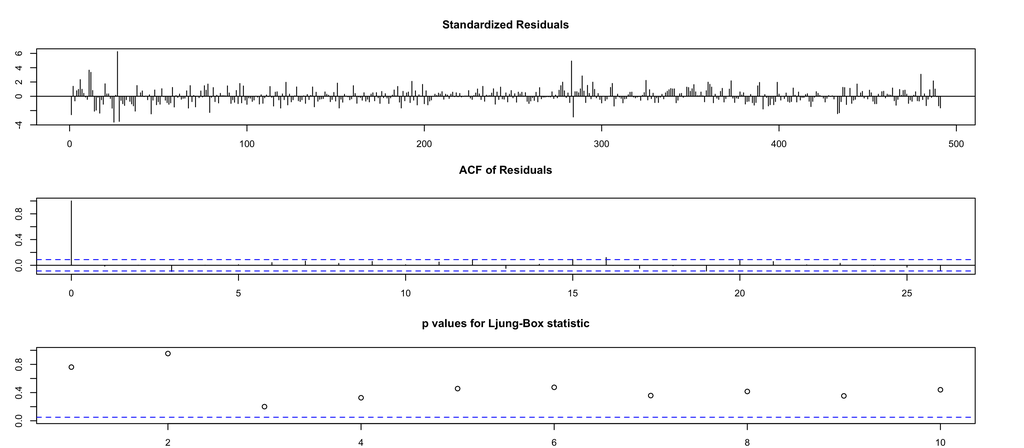

```r
par(mar=c(2,3,4,4))
tsdiag(farima)
```

```r
tsdiag_vol = function(model, lag, fitdf, span=0.5){
    par(mfrow=c(1,2));par(mar=c(3,3,3,3))
    plot(resid(model)**2, type="l", col=1,
         main = expression(residual^2))
    smoother = loess((resid(model)**2) ~ seq(1,length(resid(model))),
                     span=span)
    lines(seq(1,length(resid(model))),fitted(smoother),col=2)
    acf((resid(model)**2), main=expression("sample ACF of "~ residual^2))
    Box.test(resid(model)**2, lag = lag, type = "Ljung-Box", fitdf = fitdf)
}
tsdiag_norm = function(model){
    qqnorm(resid(model), datax = FALSE,
       xlab = "normal quantile",
       ylab = "sample quantile of residuals",
       main = "normal probability plot for residuals")
    qqline(resid(model), datax=FALSE, col = 2)
    shapiro.test(resid(model))
}
```

```
	Box-Ljung test

data:  resid(model)^2
X-squared = 56.7, df = 11, p-value = 3.779e-08
```

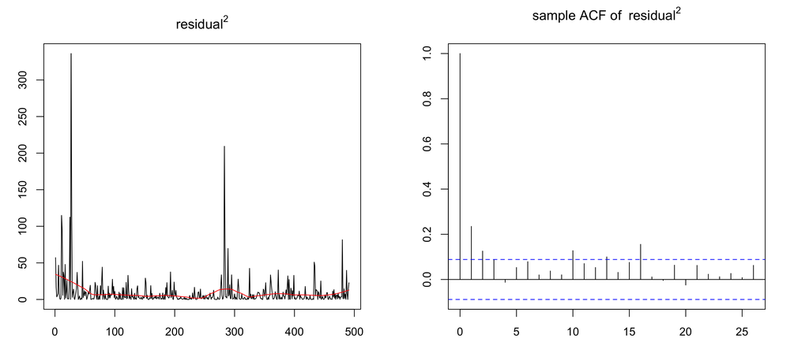

```r
tsdiag_vol(farima, lag=12, fitdf=1, span=0.25)
```

```
	Shapiro-Wilk normality test

data:  resid(model)
W = 0.94939, p-value = 6.469e-12
```

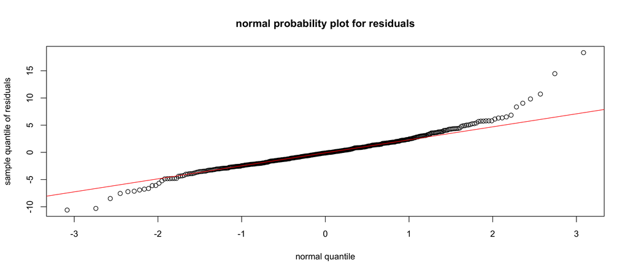

```r
tsdiag_norm(farima)
```

# 2. Regression with time series errors

- In many financial applications, we are interested in relationships between two (or more) time series
- Examples: market models such as CAPM, term structure of interest rates, etc.
- the following scenario is *very* common
- We want to find a (linear) relationship between given time series $\{x_t\}$ and $\{y_t\}$
- We fit the following regression model using OLS

\begin{align*} \begin{cases} y_t = \beta_0 + \beta_1 x_t + \eps_t,\\ \{\eps_t\}\sim \text{weak WN}(0,\sig_\eps^2) \end{cases} \end{align*}

- We run regression diagnostic, and find out that $\{\eps_t\}$ are not weak WN (using sample ACF plot and Ljung-Box test)
- Is there a problem? Can we rely on the model?
- The model is not reliable, recall the **"spurious regression"** example from Lecture 4 (section 6.4)
- In particular, correlation in the noise introduces bias in the OLS estimates and their variances
- The t-test are not reliable anymore. The R$^2$ is misleading.
- Let $\tht$ be an unknown quantity. Let $\thth$ be an estimator of $\tht$ based on a sample $\{X_1,\dots, X_N\}$. $\thth$ is **consistent** if $\thth\to\tht$ as $N\to+\infty$. A consistent estimator becomes **more accurate** as the sample size increases.
- A more significant issue with using OLS estimators when errors are correlated is that such estimators are **not consistent**. They don't become more accurate as the sample size increases.
- Time series regression (a regression model with time series response and predictors) is one of the most commonly misused statistical models in finance, since autocorrelation in the residuals is often overlooked. Do not fall into this trap!
- Let us see an example of a regression model with times series error
- Consider the 1-year US treasury constant maturity rate (y1) and 3-year US treasury constant maturity rate (y3). The data can be obtained from Federal Reserve, using the following code.

```r
library(quantmod)
getSymbols(c("WGS1YR","WGS3YR"), src="FRED", auto.assign=TRUE)
yields = na.locf(merge(WGS1YR,WGS3YR))[index(WGS1YR)]
names(yields)=c('y1','y3')
y1=as.numeric(yields$y1);
y3=as.numeric(yields$y3)
```

[output not shown]

1. 'WGS1YR'

2. 'WGS3YR'

- The time series plot and a scatter plot of the rates are given below.
- Clearly, the two rates are highly correlated.

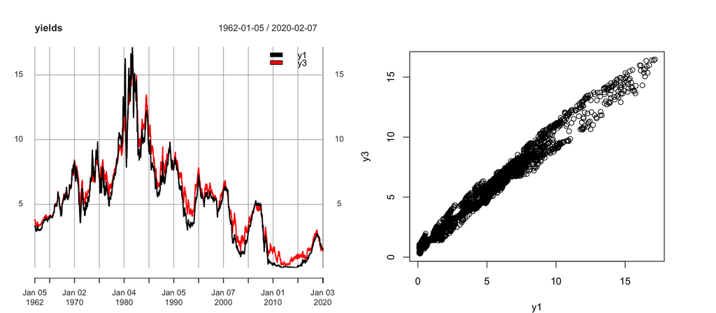

```r
par(mfrow=c(1,2));par(mar=c(4,4,4,4))
plot(yields, legend.loc='topright')
plot(y1,y3,xlab="y1", ylab="y3")
```

- Let us fit a simple line regression. The fitted model is

```r
fit_ols = lm(y3~y1)
summary(fit_ols)
```

```
Call:
lm(formula = y3 ~ y1)

Residuals:
     Min       1Q   Median       3Q      Max
-1.97737 -0.34683 -0.01301  0.35493  1.30387

Coefficients:
            Estimate Std. Error t value Pr(>|t|)
(Intercept) 0.674421   0.016387   41.16   <2e-16 ***
y1          0.949361   0.002676  354.82   <2e-16 ***
---
Signif. codes:  0 ‘***’ 0.001 ‘**’ 0.01 ‘*’ 0.05 ‘.’ 0.1 ‘ ’ 1

Residual standard error: 0.5007 on 3030 degrees of freedom
Multiple R-squared:  0.9765,	Adjusted R-squared:  0.9765
F-statistic: 1.259e+05 on 1 and 3030 DF,  p-value: < 2.2e-16
```

- Regression diagnostic reveals, however, that the residuals are highly correlated.

```
	Box-Pierce test

data:  resid(fit_ols)
X-squared = 25828, df = 9, p-value < 2.2e-16
```

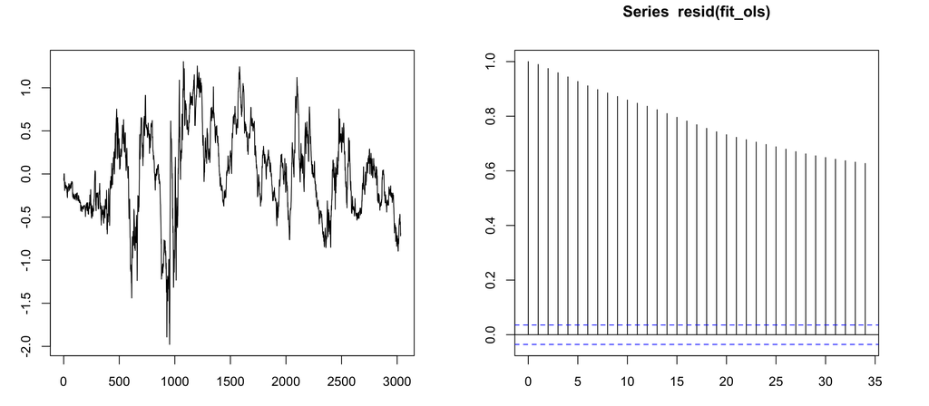

```r
par(mfrow=c(1,2));par(mar=c(3,3,3,3))
plot(resid(fit_ols), type="l")
acf(resid(fit_ols))
Box.test(resid(fit_ols), lag=10, fitdf=1)
```

- The residuals may even be unit-root non-stationary (using the KPSS test)

```r
library(tseries)
adf.test(resid(fit_ols))
pp.test(resid(fit_ols))
kpss.test(resid(fit_ols))
```

```
	Augmented Dickey-Fuller Test

data:  resid(fit_ols)
Dickey-Fuller = -4.5897, Lag order = 14, p-value = 0.01
alternative hypothesis: stationary
```

```
	Phillips-Perron Unit Root Test

data:  resid(fit_ols)
Dickey-Fuller Z(alpha) = -42.333, Truncation lag parameter = 9, p-value
= 0.01
alternative hypothesis: stationary
```

```
	KPSS Test for Level Stationarity

data:  resid(fit_ols)
KPSS Level = 1.7114, Truncation lag parameter = 9, p-value = 0.01
```

- As we mentioned earlier in the course, this is spurious regression.
- We have seen a way around this. Use the regression model on the differenced response $c3:=\Del y3$ and differenced predictor $c1 =\Del y1$

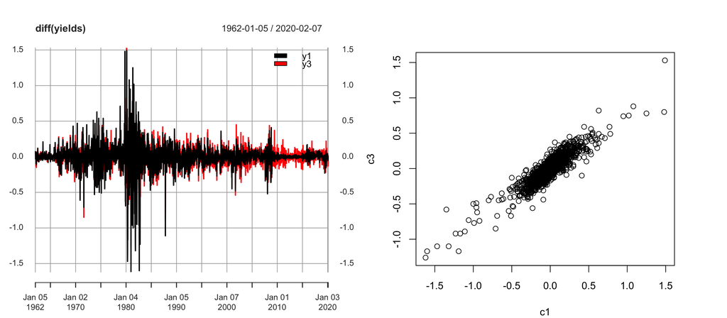

```r
c1= diff(y1);c3=diff(y3)
par(mfrow=c(1,2));par(mar=c(4,4,4,4))
plot(diff(yields), legend.loc='topright')
plot(c1,c3,xlab="c1", ylab="c3")
```

- The fitted model is

```r
fit_diff_ols = lm(c3~c1)
summary(fit_diff_ols)
```

```
Call:
lm(formula = c3 ~ c1)

Residuals:
     Min       1Q   Median       3Q      Max
-0.42574 -0.03404 -0.00175  0.03392  0.49383

Coefficients:
              Estimate Std. Error t value Pr(>|t|)
(Intercept) -0.0002997  0.0012073  -0.248    0.804
c1           0.7952078  0.0070488 112.814   <2e-16 ***
---
Signif. codes:  0 ‘***’ 0.001 ‘**’ 0.01 ‘*’ 0.05 ‘.’ 0.1 ‘ ’ 1

Residual standard error: 0.06647 on 3029 degrees of freedom
Multiple R-squared:  0.8078,	Adjusted R-squared:  0.8077
F-statistic: 1.273e+04 on 1 and 3029 DF,  p-value: < 2.2e-16
```

- The residuals, however, are still correlated (though not as bad as the previous model)

```
	Box-Pierce test

data:  resid(fit_diff_ols)
X-squared = 153.57, df = 9, p-value < 2.2e-16
```

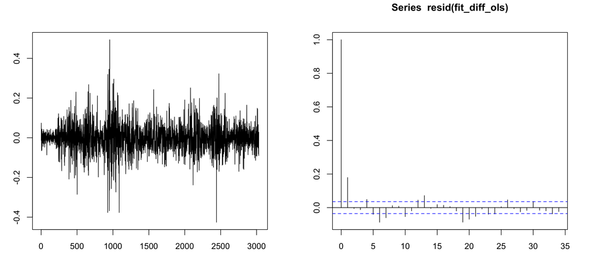

```r
par(mfrow=c(1,2));par(mar=c(3,3,3,3))
plot(resid(fit_diff_ols), type="l")
acf(resid(fit_diff_ols))
Box.test(resid(fit_diff_ols), lag=10, fitdf=1)
```

- The residuals are stationary.

```r
kpss.test(resid(fit_diff_ols))
```

```
	KPSS Test for Level Stationarity

data:  resid(fit_diff_ols)
KPSS Level = 0.065376, Truncation lag parameter = 9, p-value = 0.1
```

- **Idea:** The ACF plot of the residuals indicates an MA(1) (or MA(7)...) model for the residuals. Can we use an ARMA model for the residuals instead of the weak WN assumption?
- This is possible. Such models are called the **ARIMAX** model ("X" refers to the additional predictor X)

\begin{align*} \begin{cases} Y_t = \beta_0 + \beta_1 X_t + a_t\\ (1-\sum_{k=1}^p \ph_k B^k) \Del^d a_t = (1+\sum_{\ell=1}^q \tht_\ell B^\ell) \eps_t\\ \{\eps_t\} \sim \text{weak WN}(0, \sig_\eps^2) \end{cases} \end{align*}

- $\{a_t\}$ is the error in the regression and is an ARIMA(p,d,q) process
- Note that we need to simultaneously estimate $\beta_0$, $\beta_1$, $\ph_1, \dots, \ph_p$, and $\tht_1,\dots, \tht_q$
- It is wrong to fit a ARIMA model to the residuals of the OLS regression!
- We can write the ARIMAX model as follows

\begin{align*} \begin{cases} (1-\sum_{k=1}^p \ph_k B^k) \Del^d \left(Y_t - \beta_0 - \beta_1 X_t\right) = (1+\sum_{\ell=1}^q \tht_\ell B^\ell) \eps_t\\ \{\eps_t\} \sim \text{weak WN}(0, \sig_\eps^2) \end{cases} \end{align*}

- The following form, however, is **not** equivalent to the ARIMAX model (even for $d=0$)

\begin{align*} \begin{cases} Y_t = \beta_0 + \beta_1 X_t + \sum_{k=1}^p \ph_k Y_{t-k} + \eps_t + \sum_{\ell=1}^q \tht_\ell \eps_{t-\ell}\\ \{\eps_t\} \sim \text{weak WN}(0, \sig_\eps^2) \end{cases} \end{align*}

- We can fit ARIMAX models with `arima()` function by passing the predictor using the `xreg=` argument
- For example, to fit an ARIMAX(0,0,1) model to $c3$ with $c1$ as the predictor, we use

```r
arima(c3, order = c(0, 0, 1), xreg = c1)
```

```
Call:
arima(x = c3, order = c(0, 0, 1), xreg = c1)

Coefficients:
         ma1  intercept      c1
      0.1850    -0.0003  0.7968
s.e.  0.0176     0.0014  0.0072

sigma^2 estimated as 0.004268:  log likelihood = 3968.77,  aic = -7929.54
```

- We may also use the `auto.arima()` function to fit ARIMAX models by passing the predictor with `xreg=` argument.

```r
fit_arimax = auto.arima(y3, max.p=20, xreg = y1, max.q = 20, max.d=3, ic="bic")
fit_arimax
```

```
Series: y3
Regression with ARIMA(0,1,1) errors

Coefficients:
         ma1    xreg
      0.1850  0.7968
s.e.  0.0176  0.0072

sigma^2 estimated as 0.004271:  log likelihood=3968.75
AIC=-7931.5   AICc=-7931.49   BIC=-7913.45
```

- The model diagnostic is similar to other ARIMA models.
- It looks like the model is not adequate. We may increase the MA order to remedy this. However, the BIC criterion indicates that doing so does not add much to the model predictive power.

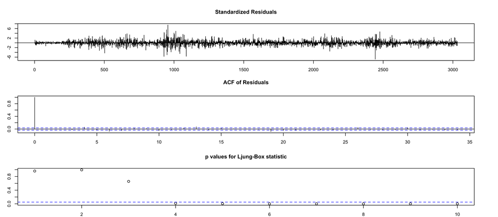

```r
par(mar=c(2,3,4,4))
tsdiag(fit_arimax, gof=10)
```

- The volatility does not seem to be constant.

```
	Box-Ljung test

data:  resid(model)^2
X-squared = 804.22, df = 10, p-value < 2.2e-16
```

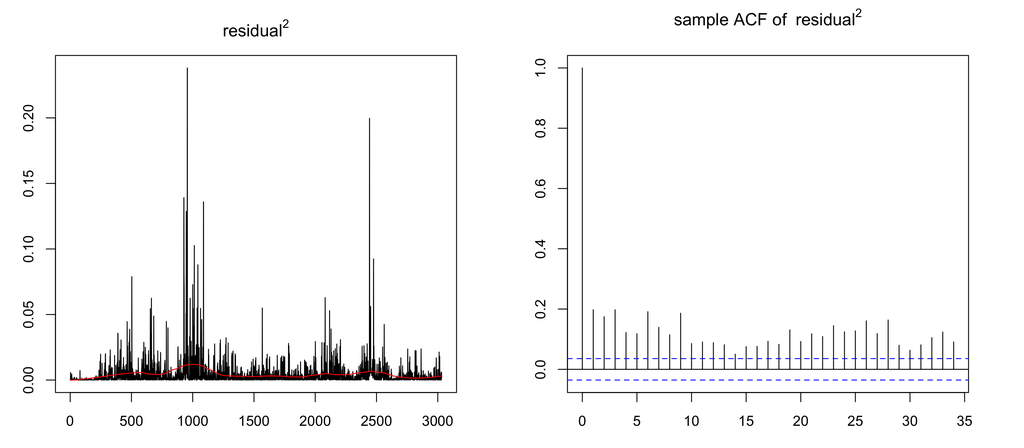

```r
tsdiag_vol(fit_arimax, lag=12, fitdf=2, span=0.25)
```

- The errors are not normal.

```
	Shapiro-Wilk normality test

data:  resid(model)
W = 0.95923, p-value < 2.2e-16
```

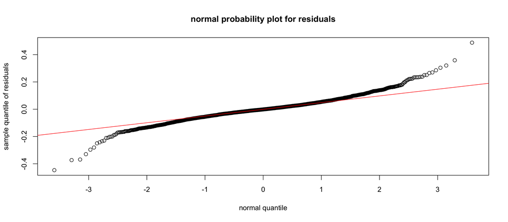

```r
tsdiag_norm(fit_arimax)
```

# 3. Conditional variance and volatility

- Our next goal is to model and estimate volatility (vol) of assets
- Vol, denoted by $\{\sig_t\}$, is the conditional standard deviation of the returns of an asset. For a univariate time series models, we have

\begin{align*} \sig_t = \sqrt{\Var(r_t|r_{t-1},\dots)} \end{align*}

- Vol have many applications in finance including, asset pricing, risk management, asset allocation, and interval forecasts
- Key characteristic of vol: **not directly observable**
- Let us see how to detect non-constant volatility

'^DJI'

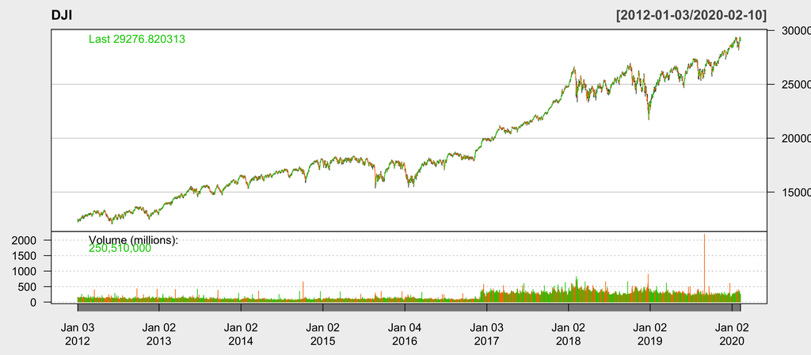

```r
getSymbols("^DJI", from="2012-01-03", src="yahoo")
chartSeries(DJI, theme="white")
```

- The returs of `DJI` clearly show variance clustering

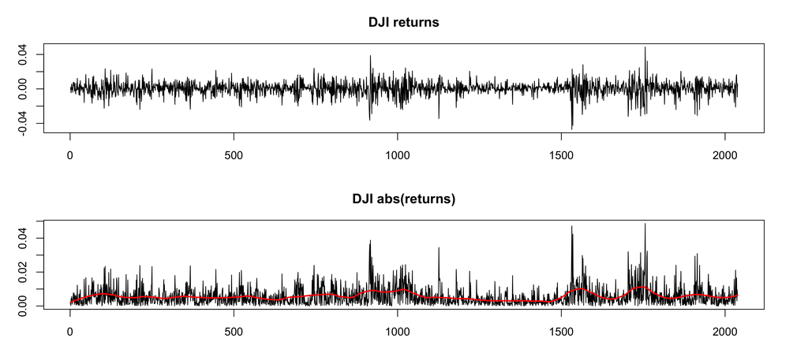

```r
rtn=coredata(na.omit(diff(log(DJI$DJI.Adjusted))))
par(mfrow=c(2,1));par(mar=c(3,3,3,3))
plot(rtn, type="l", col=1, main = "DJI returns")
plot(abs(rtn), type="l", col=1, main = "DJI abs(returns)")
smoother = loess(abs(rtn) ~ seq(1,length(rtn)), span=0.1)
lines(seq(1,length(rtn)),fitted(smoother),col=2, lwd=2)
```

- Let us check if the returns are weak WN (are they?)

```
	Box-Ljung test

data:  rtn
X-squared = 12.641, df = 10, p-value = 0.2444
```

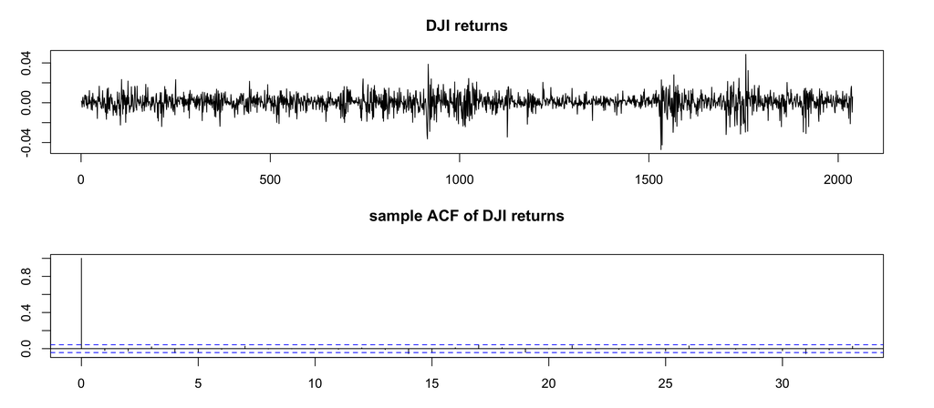

```r
par(mfrow=c(2,1));par(mar=c(3,3,3,3))
plot(rtn, type="l", col=1, main = "DJI returns")
acf(rtn, main="sample ACF of DJI returns")
Box.test(rtn, lag=10, type = "Ljung-Box")
```

- Next, we test if the returns have non-constant conditional variance, also refered to as **hetroskedasticity**

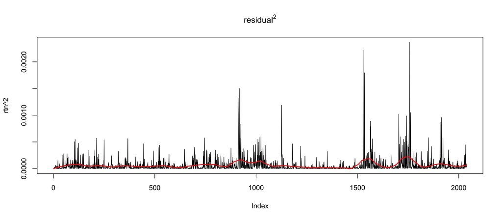

```r
plot(rtn**2, type="l", col=1, main = expression(residual^2))
smoother = loess((rtn**2) ~ seq(1,length(rtn)), span=0.1)
lines(seq(1,length(rtn)),fitted(smoother),col=2,lwd=2)
```

- To test for heteroskedisticity, we check for autocorrelation in squared returns

```
	Box-Ljung test

data:  (rtn^2)
X-squared = 427.86, df = 5, p-value < 2.2e-16
```

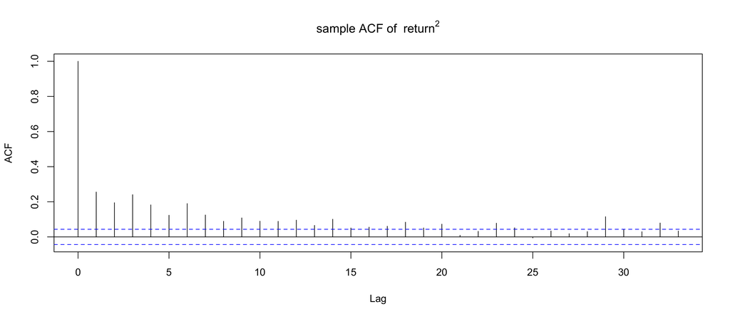

```r
acf((rtn**2), main=expression("sample ACF of "~ return^2))
Box.test((rtn**2), lag=5, type = "Ljung-Box")
```

- Many asset returns are not serially correlated (they are weak white noise), however, they are dependent and show volatility clustering
- There are three main approaches to estimate vol:
  - Using high-frequency data: e.g. **"realized vol"** where one uses intraday data to estimate daily vol
  - Using options data: e.g. implied vol indices such as VIX
  - Econometric modeling, which we discuss in this lecture

# 3.1. ARCH(1) processes

- Let $\{\eps_t\}$ be an i.i.d. white noise process, such that

\begin{align*} \Eb(\eps_t|\eps_{t-1},\dots) = 0 \quad\quad\text{ and }\quad\quad \Var(\eps_t|\eps_{t-1},\dots) = 1 \end{align*}

- We say that $\{\eps_t\}$ is **"conditionally homoskedastic,"** since its conditional variance is constant
- An **"autoregressive conditionally heteroskedastic of order 1"** - or ARCH(1) - process is a process $\{a_t\}$ given by

\begin{align*} a_t = \eps_t\sqrt{\om + \al\,a_{t-1}^2};\quad t\in\{2,3,\dots\} \end{align*}

- We may equivalently write

\begin{align*} a_t^2 = \eps_t^2\,(\om + \al\,a_{t-1}^2);\quad t\in\{2,3,\dots\} \end{align*}

- Here, it is assumed that $\om>0$ and $\al\ge 0$
- The conditional mean of $\{a_t\}$ is zero:

\begin{align} \begin{split} \Eb(a_t|a_{t-1}\dots) &= \Eb\left(\eps_t\sqrt{\om + \al\,a_{t-1}^2}\Big|a_{t-1}\dots\right)\\ &= \Eb\left(\eps_t|a_{t-1}\dots\right)\sqrt{\om + \al\,a_{t-1}^2} = 0 \end{split} \tag{$\star$} \end{align}

- $\{a_t\}$ have the **volatility clustering** behavior.
- To see this, let us calculate the conditional variance:

\begin{align*} \sig_t^2 &:= \Var(a_t|a_{t-1}\dots) \\\\ &= \Var\left(\eps_t\sqrt{\om + \al\,a_{t-1}^2}\Big|a_{t-1}\dots\right)\\\\ &= \Var\left(\eps_t|a_{t-1}\dots\right)\left(\om + \al\,a_{t-1}^2\right)\\\\ &= \om + \al\,a_{t-1}^2 \end{align*}

- So, large values (respectively, small values) of $a_{t-1}$ impose large values (respectively, small values) of $\sig_t$, which, in turn, impose large values (respectively, small values) of $a_t$
- In other words, unusual values of volatility tends to persists. This is the **volatility clustering** behavior that we have seen in financial return series
- Note that volatility clustering is related to changing **conditional** variance
- The unconditional variance of $\{a_t\}$ can be constant.
- Indeed, it can be shown that if $0<\al<1$, then $\{a_t\}$ is stationary
- Assuming stationarity, we can easily find the unconditional variance:

\begin{align*} \gam(0):=\Var(a_t) &= \Eb(a_t^2)\\\\ &= \Eb\left(\eps_t^2(\om+\al\,a_{t-1}^2)\right)\\\\ &= \Eb(\eps_t^2)\,\Eb(\om+\al\,a_{t-1}^2)\\\\ &= \om+\al\,\gam(0) \end{align*}

- We then obtain $\displaystyle\gam(0) = \frac{\om}{1-\al}$
- Furthermore, the process $\{a_t\}$ is serially uncorrelated, that is, $\gam(h) = \Cov(a_t,a_{t-h})=0$, for all $h\in\{1,2,\dots\}$
- To show this, we use the **tower property** of the condition expectation. For random variables $X$ and $Y$, $\Eb(X) = \Eb\big(\Eb(X|Y)\big)$
- We have:

\begin{align*} \gam(h) := \Cov(a_t, a_{t-h}) &= \Eb\left(a_t a_{t-h}\right)\\\\ &= \Eb\Big(\Eb(a_t\,a_{t-h}|a_{t-1},\dots)\Big)\\\\ &= \Eb\Big(a_{t-h}\Eb(a_t|a_{t-1},\dots)\Big) = 0 \end{align*}

- In the last step, we used Equation $(\star)$: $\Eb(a_t|a_{t-1},\dots)=0$
- To summarize, we found that if $\{a_t\}$ is stationary (i.e. $0<\al<1$ and $\om>0$), then $\{a_t\}$ is a weak WN$(0,\frac{\om}{1-\al})$
- Although $\{a_t\}$ is not autocorrelated, it is serially dependent!
- In particular $a_t^2 = \eps_t^2(\om+\al\,a_{t-1}^2)$. Thus, $\{a_t\}$ has variance clustering
- These are the properties of asset returns that we saw earlier
- As we mentioned, $\{a_t\}$ is not autocorrelated
- However, $\{a_t^2\}$ is autocorrelated and is actually an AR(1) process
- To see this, define $\eta_t := a_t^2 - \sig_t^2 = a_t^2 - (\om+\al\,a_{t-1}^2)$
- One can show that $\{\eta_t\}$ is a weak WN
- We then obtain the AR(1) representatin of $\{a_t^2\}$

\begin{align*} a_t^2 = \sig_t^2 + a_t^2 - \sig_t^2 = \om+\al\,a_{t-1}^2 + \eta_t \end{align*}

- Thus, $\{a_t\}$ is an ARCH(1) process if $\{a_t^2\}$ is an AR(1) process. This relationship generalizes for other ARCH and GARCH processes

## 3.2. ARCH(p) processes

- In an ARCH(p) model, $\{a_t^2\}$ is an AR(p) process
- Form of an ARCH(p) process:

\begin{align*} \begin{cases} a_t = \sig_t\,\eps_t,\quad \eps_t\overset{i.i.d.}{\sim} F_\eps,\\ \sig_t^2 = \om + \al_1\,a_{t-1}^2 + \dots + \al_p\,a_{t-p}^2. \end{cases} \end{align*}

- Here, $F_\eps$ can be any distribution function as long as $\Eb(\eps_t)=0$ and $\Var(\eps_t)=1$
- We assume the $\om>0$, and $\al_i\ge0$
- Under some additional technical conditions, $\{a_t\}$ is a weakly stationary process. A weakly stationary ARCH$(p)$ process is a weak WN. However, they are serially dependent and show volatility clustering

## 3.3. Building an ARCH(p) model

- **Step 1:** Modeling the mean effect and testing for the ARCH effects:
  - Fit an ARIMA model (most asset returns are weak WN, so this step usually ends up with a very simple model)
  - Let $\{\ah_t\}$ be the residuals of ARIMA model. To detect ARCH effect (i.e. vol clustering), use Ljung-Box test on $\{\ah_t^2\}$ to check for autocorrelation. Existence of autocorrelation in $\{\ah_t^2\}$ indicates ARCH effect
- **Step 2:** Determining the order of ARCH:
  - Use sample PACF of $\{\ah_t^2\}$. The PACF should drop to zero at the ARCH oder
  - In practice, simply try some reasonable orders
- **Step 3:** Estimation:
  - The estimation is done using conditional MLE
  - You can use several packages in R, for example `rugarch` (see the textbook) or `fGarch` (which we use today). These packages allow for error distributions other than normal
- **Step 4:** Model checking
  - Let $\{\epsh_t\}$ be the standardized residuals for the model fitted in Step 3
  - Use Ljung-Box tests for $\{\epsh_t\}$ and $\{\epsh_t^2\}$ to check that the standardized residuals are i.i.d. white noise
  - Also, check that the marginal distribution of $\{\epsh_t\}$ matches the distribution assumed for MLE in Step 3 (use an appropriate QQ plot or test)
- Let us fit an ARCH(p) model to the DJI returns time series

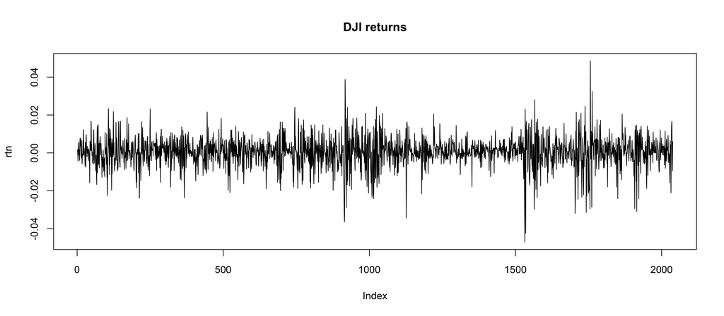

```r
plot(rtn, type="l", col=1, main = "DJI returns")
```

- **Step 1:** Modeling the mean effect & testing for the ARCH effect
- The `auto.arima()` function suggests a weak WN

```r
library(forecast)
fit=auto.arima(rtn, max.p = 20, max.q = 20, max.d = 2, ic="bic")
print(fit)
```

```
Series: rtn
ARIMA(0,0,0) with zero mean

sigma^2 estimated as 6.364e-05:  log likelihood=6954.11
AIC=-13906.23   AICc=-13906.23   BIC=-13900.61
```

- Generally, an ARIMA diagnostic will be conducted next, not necessary here
- ACF plot and Ljung-Box test for squared residuals indicates heteroskedasticity

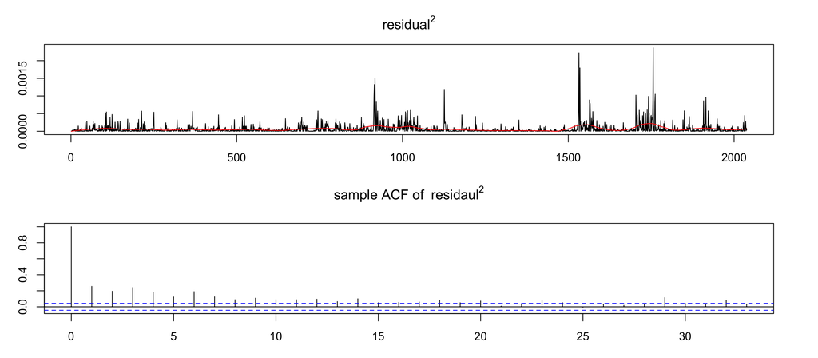

```r
par(mfrow=c(2,1));par(mar=c(3,3,3,3))
plot(resid(fit)**2, type="l", col=1, main = expression(residual^2))
smoother = loess((resid(fit)**2) ~ seq(1,length(resid(fit))), span=0.1)
lines(seq(1,length(resid(fit))),fitted(smoother),col=2)
acf((resid(fit)**2), main=expression("sample ACF of "~ residaul^2))
```

```r
Box.test(resid(fit)**2, lag = 5, type = "Ljung-Box")
```

```
	Box-Ljung test

data:  resid(fit)^2
X-squared = 427.86, df = 5, p-value < 2.2e-16
```

- **Step 2:** To determine the ARCH order, we check the PACF of residual$^2$ of the model fitted in Step 1
- Perhaps ARCH(4) or ARCH(6)?

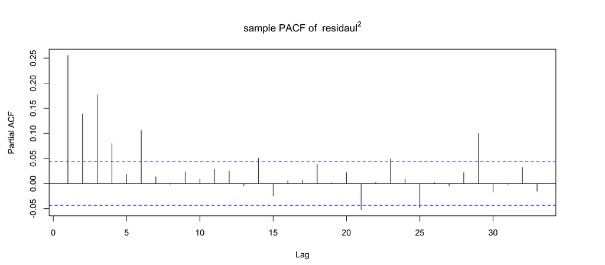

```r
par(mfrow=c(1,1));par(mar=c(4.5,4.5,4.5,4.5))
pacf((resid(fit)**2), main=expression("sample PACF of "~ residaul^2))
```

- **Step 3:** Model estimation
- Let us fit an ARHC(4) model using `garchFit()` function of the `fGarch` package
- The fitted model is

```r
library(fGarch)
arch4 = garchFit(~garch(4,0), data=resid(fit), trace = F)
# trace=F reduces the amount of output
summary(arch4)
```

```
Title:
 GARCH Modelling

Call:
 garchFit(formula = ~garch(4, 0), data = resid(fit), trace = F)

Mean and Variance Equation:
 data ~ garch(4, 0)
<environment: 0x7fb708334e68>
 [data = resid(fit)]

Conditional Distribution:
 norm

Coefficient(s):
        mu       omega      alpha1      alpha2      alpha3      alpha4
7.5432e-04  2.1267e-05  1.7165e-01  1.5580e-01  2.0027e-01  1.8755e-01

Std. Errors:
 based on Hessian

Error Analysis:
        Estimate  Std. Error  t value Pr(>|t|)
mu     7.543e-04   1.359e-04    5.552 2.82e-08 ***
omega  2.127e-05   1.681e-06   12.653  < 2e-16 ***
alpha1 1.717e-01   2.844e-02    6.036 1.58e-09 ***
alpha2 1.558e-01   3.082e-02    5.055 4.31e-07 ***
alpha3 2.003e-01   3.426e-02    5.846 5.04e-09 ***
alpha4 1.876e-01   3.609e-02    5.196 2.03e-07 ***
---
Signif. codes:  0 ‘***’ 0.001 ‘**’ 0.01 ‘*’ 0.05 ‘.’ 0.1 ‘ ’ 1

Log Likelihood:
 7170.209    normalized:  3.518258

Description:
 Tue Feb 11 14:18:29 2020 by user:


Standardised Residuals Tests:
                                Statistic p-Value
 Jarque-Bera Test   R    Chi^2  255.5997  0
 Shapiro-Wilk Test  R    W      0.9794322 0
 Ljung-Box Test     R    Q(10)  6.697718  0.7536407
 Ljung-Box Test     R    Q(15)  16.19654  0.3691109
 Ljung-Box Test     R    Q(20)  22.39633  0.3193977
 Ljung-Box Test     R^2  Q(10)  11.76086  0.30138
 Ljung-Box Test     R^2  Q(15)  17.48821  0.2905262
 Ljung-Box Test     R^2  Q(20)  20.11148  0.4509756
 LM Arch Test       R    TR^2   15.02398  0.2401276

Information Criterion Statistics:
      AIC       BIC       SIC      HQIC
-7.030627 -7.014082 -7.030644 -7.024558
```

- **Step 4:** The **standardized residuals** are the estimates $\eps_t$ in the ARCH model. We should check that they are i.i.d. Gaussian white noise.
- The are serially uncorrelated based on the sample ACF plot and Ljung-Box test statistics included in the model output above.

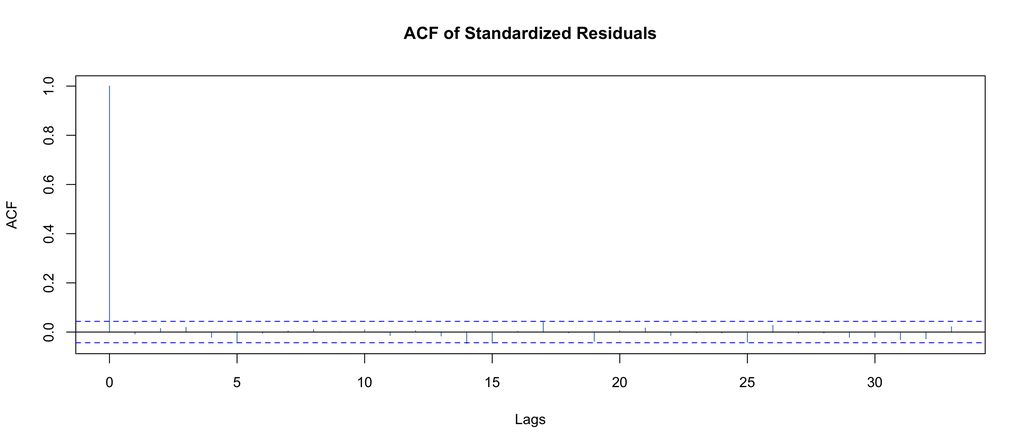

```r
plot(arch4, which=10)
```

- The sample ACF of standardized residual$^2$ indicates that they are also not autocorrelated. This is also confirmed by the Ljun-Box test stats for standardized residual$^2$ in the model output above.

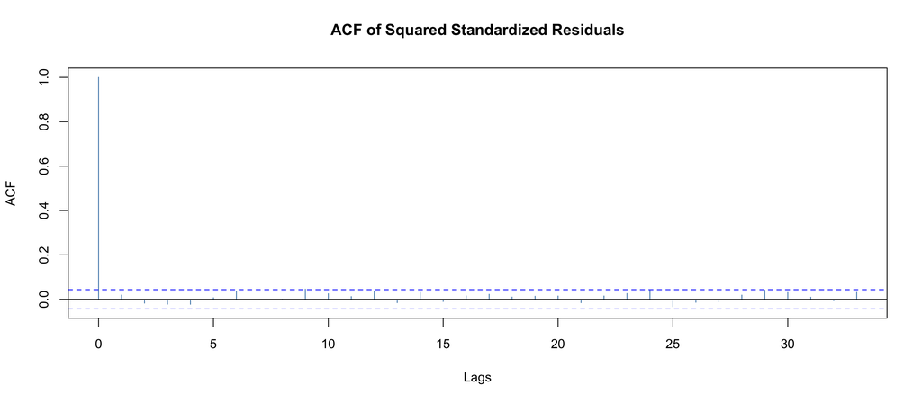

```r
plot(arch4, which=11)
```

- Finally, we check for normality.
- Based on the normal plot and the normality test in the model output, standardized residuals are not normal (they are fat tailed).

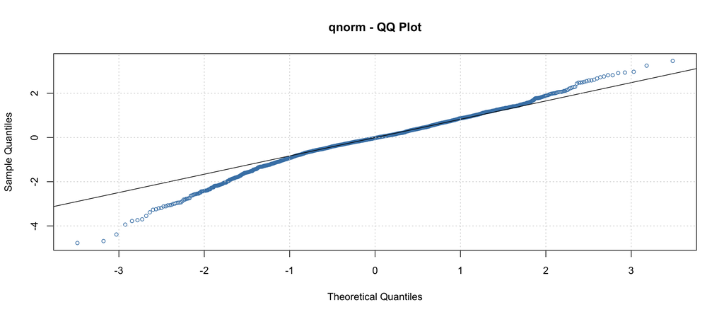

```r
plot(arch4, which=13)
```

- Let us fit an ARCH model assuming residual with t-distribution instead of normal (to correcting for heavy tails)
- In the `garchFit()` function, we can indicate the distribution of error by using the `cond.dist =` argument. For example, `cond.dist = "std"` indicates a student t distribution.
- R will estimate the degree of freedom of the t-distribution!
- The fitted model is:

```r
arch4_tdist = garchFit(~garch(4,0), data=resid(fit),
                 cond.dist = "std", # using standard t distribution
                 trace = F)
summary(arch4_tdist)
```

```
Title:
 GARCH Modelling

Call:
 garchFit(formula = ~garch(4, 0), data = resid(fit), cond.dist = "std",
    trace = F)

Mean and Variance Equation:
 data ~ garch(4, 0)
<environment: 0x7fb70439eee8>
 [data = resid(fit)]

Conditional Distribution:
 std

Coefficient(s):
        mu       omega      alpha1      alpha2      alpha3      alpha4
8.0545e-04  2.0859e-05  1.7364e-01  1.9022e-01  2.3100e-01  1.8269e-01
     shape
5.0901e+00

Std. Errors:
 based on Hessian

Error Analysis:
        Estimate  Std. Error  t value Pr(>|t|)
mu     8.054e-04   1.268e-04    6.354 2.09e-10 ***
omega  2.086e-05   2.191e-06    9.520  < 2e-16 ***
alpha1 1.736e-01   3.939e-02    4.408 1.04e-05 ***
alpha2 1.902e-01   4.123e-02    4.614 3.96e-06 ***
alpha3 2.310e-01   4.769e-02    4.844 1.27e-06 ***
alpha4 1.827e-01   4.543e-02    4.022 5.78e-05 ***
shape  5.090e+00   6.157e-01    8.267 2.22e-16 ***
---
Signif. codes:  0 ‘***’ 0.001 ‘**’ 0.01 ‘*’ 0.05 ‘.’ 0.1 ‘ ’ 1

Log Likelihood:
 7226.555    normalized:  3.545905

Description:
 Tue Feb 11 14:19:17 2020 by user:


Standardised Residuals Tests:
                                Statistic p-Value
 Jarque-Bera Test   R    Chi^2  266.6074  0
 Shapiro-Wilk Test  R    W      0.979133  0
 Ljung-Box Test     R    Q(10)  6.701138  0.7533259
 Ljung-Box Test     R    Q(15)  16.50343  0.3494044
 Ljung-Box Test     R    Q(20)  22.60683  0.3085097
 Ljung-Box Test     R^2  Q(10)  12.30368  0.2652465
 Ljung-Box Test     R^2  Q(15)  17.04757  0.3160289
 Ljung-Box Test     R^2  Q(20)  19.03548  0.519521
 LM Arch Test       R    TR^2   14.93961  0.2447554

Information Criterion Statistics:
      AIC       BIC       SIC      HQIC
-7.084941 -7.065639 -7.084965 -7.077861
```

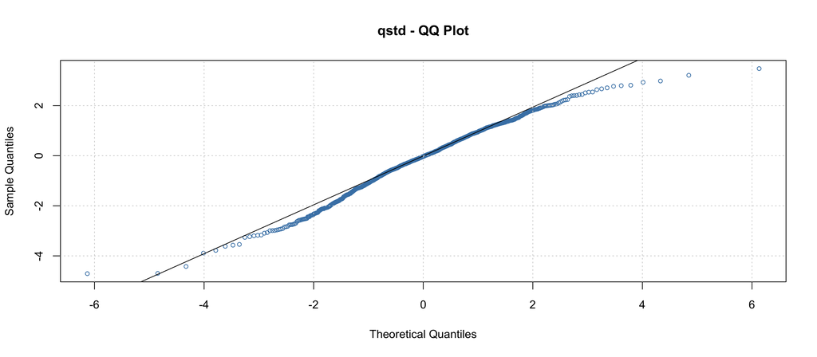

```r
plot(arch4_tdist, which=13)
```